# PA1_template.Rmd

Jiangpeng Pan

6/14/2020

1. Loading and preprocessing the data Show any code that is needed to
2. Load the data (i.e.read.csv()) Process/transform the data (if necessary) into a format suitable for your analysis

```r
if (!file.exists("activity.csv") )
    {
     url <- 'http://d396qusza40orc.cloudfront.net/repdata%2Fdata%2Factivity.zip'
     download.file(url,destfile='repdata%2Fdata%2Factivity.zip',mode='wb')
     unzip('repdata%2Fdata%2Factivity.zip')
    }

data <- read.csv("activity.csv")
```

What is mean total number of steps taken per day? 1. Calculate the total number of steps taken per day 2. If you do not understand the difference between a histogram and a barplot, research the difference between them. Make a histogram of the total number of steps taken each day 3. Calculate and report the mean and median of the total number of steps taken per day

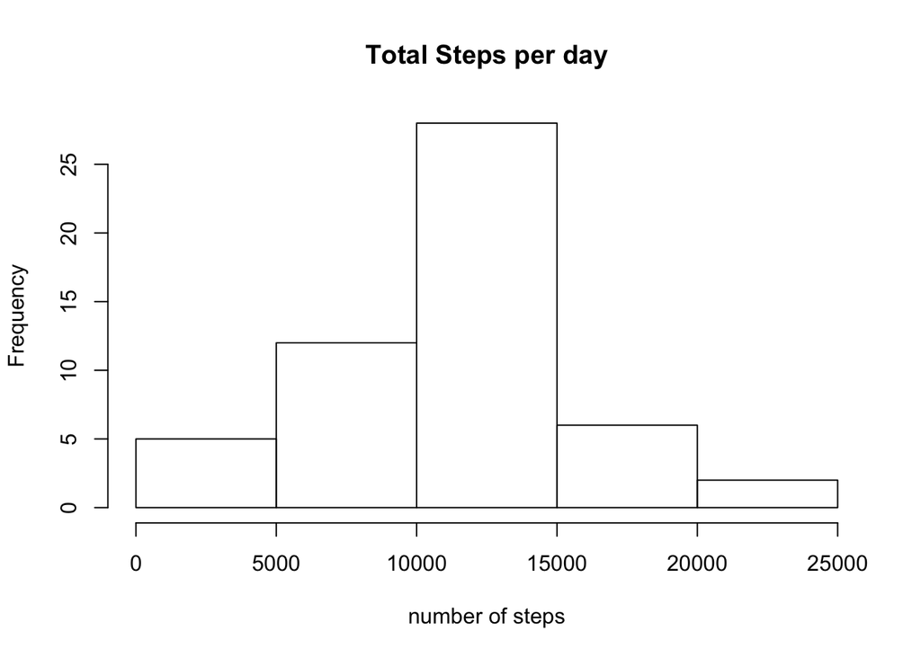

````r
StepsByDays <- aggregate(steps ~ date, data, sum)
###```{r pressure, echo=FALSE}
hist(StepsByDays$steps, main = "Total Steps per day", xlab = "number of steps")
````

```r
### mean and median
mean1 <- mean(StepsByDays$steps)
mean1
```

```
## [1] 10766.19
```

```r
median1 <- median(StepsByDays$steps)
median1
```

```
## [1] 10765
```

What is the average daily activity pattern? 1. Make a time series plot (i.e. type = “l”) of the 5-minute interval (x-axis) and the average number of steps taken, averaged across all days (y-axis) 2. Which 5-minute interval, on average across all the days in the dataset, contains the maximum number of steps?

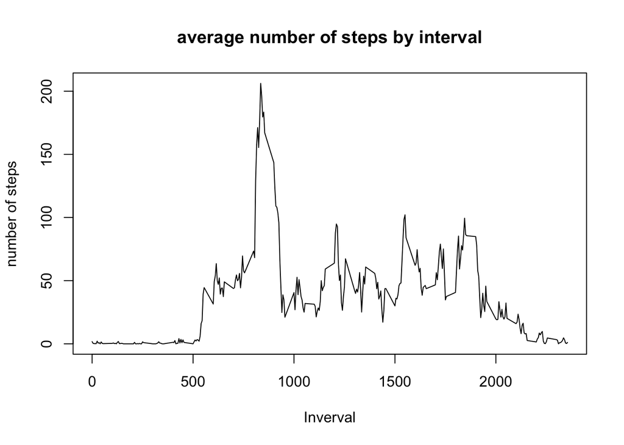

```r
interval <- aggregate(steps ~ interval, data, mean)
plot(interval$interval, interval$steps, type = 'l', main = "average number of steps by interval", xlab = 'Inverval', ylab = "number of steps")
```

```r
## maximum
max_interval <- interval[which.max(interval$steps), 1]
max_interval
```

```
## [1] 835
```

the interval with most steps is 835.

Imputing missing values 1. Calculate and report the total number of missing values in the dataset (i.e. the total number of rows with NAs)

```r
totalNA <- sum(!complete.cases(data))
totalNA
```

```
## [1] 2304
```

2. Devise a strategy for filling in all of the missing values in the dataset. The strategy does not need to be sophisticated. For example, you could use the mean/median for that day, or the mean for that 5-minute interval, etc.

```r
step_mean <- aggregate(steps ~ interval, data, mean)
fill_NA <- numeric()
for (i in 1:nrow(data)) {
  obs <- data[i, ]
  if (is.na(obs$steps)) {
    steps <- subset(step_mean, interval == obs$interval)$steps
  } else {
    steps <- obs$steps
  }
  fill_NA <- c(fill_NA, steps)
}
```

3. Create a new dataset that is equal to the original dataset but with the missing data filled in.

```r
new <- data
new$steps <- fill_NA
```

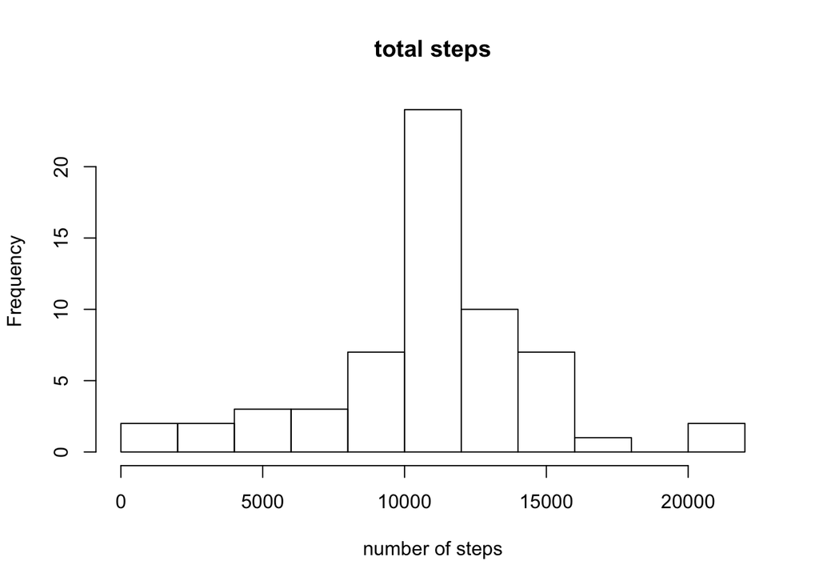

```r
new_step <- aggregate(steps ~ date, new, sum, na.rm = TRUE)
hist(new_step$steps, main = "total steps", breaks = 15, xlab = 'number of steps')
```

```r
new_mean <- mean(new_step$steps)
new_median <- median(new_step$steps)
new_mean_diff <- new_mean - mean1
new_median_diff <- new_median - median1
```

Are there differences in activity patterns between weekdays and weekends?

1. Create a new factor variable in the dataset with two levels – “weekday” and “weekend” indicating whether a given date is a weekday or weekend day.

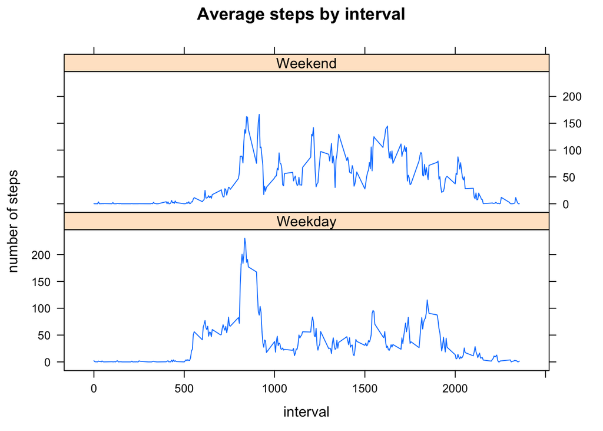

```r
library(lattice)
weekdays <- c("Monday", "Tuesday", "Wednesday", "Thursday", "Friday")
new$dow = as.factor(ifelse(is.element(weekdays(as.Date(new$date)), weekdays), "Weekday", "Weekend"))
last_Total <- aggregate(steps ~ interval + dow, new, mean)
xyplot(last_Total$steps ~ last_Total$interval|last_Total$dow, main = "Average steps by interval", xlab = "interval", ylab = "number of steps", layout = c(1,2), type = "l")
```